# Informe Hoja de Trabajo 4

Marco Ramirez 19588, Alfredo Quezada 191002, Estuardo Hernandez 19202

14/3/2022

# Modelos de Regresión Lineal

### Elabore un modelo de regresión lineal utilizando el conjunto de entrenamiento que hizo para predecir los precios de las casas. Explique los resultados a los que llega. Muestre el modelo gráficamente. El experimento debe ser reproducible por lo que debe fijar que los conjuntos de entrenamiento y prueba sean los mismos siempre que se ejecute el código.

```r
#Definimos el porcentaje de datos de prueba
porcentaje<-0.7
#Ya que lo que deseamos es que el experimento sea repetible asignamos una semilla
set.seed(123)

#Calculo de percentiles
data<-read.csv('train.csv')
percentil <- quantile(data$SalePrice)


#Percentiles
estado<-c('Estado')
data$Estado<-estado


#Economica=0
#Intermedia=1
#Cara=2
data <- within(data, Estado[SalePrice<=129975] <- 0)

data$Estado[(data$SalePrice>129975 & data$SalePrice<=163000)] <- 1
data$Estado[data$SalePrice>163000] <- 2


#Regresion
corte <- sample(nrow(data),nrow(data)*porcentaje)
#Creamos nuestros datos de prueba y entrenamiento
train<-data[corte,]
test<-data[-corte,]


#Regresion lineal
fitLMPW<-lm(SalePrice~ ., data = train[,c("GrLivArea","YearBuilt","BsmtUnfSF","TotalBsmtSF","GarageArea","YearRemodAdd", "SalePrice","LotArea")])

predL<-predict(fitLMPW, newdata = test)


#Verificando la predicci?n
resultados<-data.frame(test$SalePrice,predL)
pregunta2<-head(resultados, n=5)
grafica1<-ggplot(data=train,mapping = aes(x=SalePrice,y=GrLivArea ))+
  geom_point(color='red',size=2)+
  geom_smooth(method = 'lm',se=TRUE,color='black')+
  labs(title = 'Precio de venta ~ Pies cuadrados de vivienda',x="Precio de venta",y='Pies cuadrados de venta')+
  theme_bw()+theme(plot.title = element_text(hjust = 0.5))
```

```r
pregunta2
```

```
##    test.SalePrice    predL
## 1          208500 221168.7
## 3          223500 227475.4
## 7          307000 257880.7
## 14         279500 235937.2
## 15         157000 143342.6
```

En la tabla mostrada anteriormente, se observa que la predicción de los precios de las casas no se alejan mucho de los precios verdaderos, por lo que se concluye que las variables seleccionadas para realizar la predicción tiene correlación con el precio de la casa, y por consiguiente el modelo está bien.

### Analice el modelo. Determine si hay multicolinealidad en las variables, y cuáles son las que aportan al modelo, por su valor de significación. Haga un análisis de correlación de las variables del modelo y especifique si el modelo se adapta bien a los datos. Explique si hay sobreajuste (overfitting) o no.

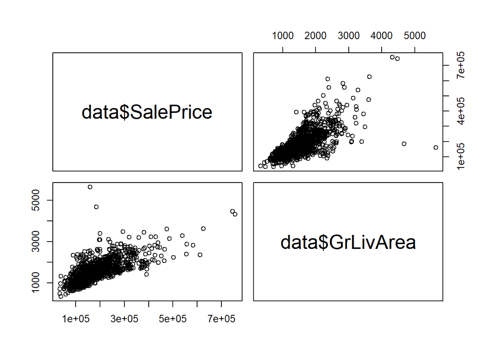

```r
pairs(data$SalePrice ~ data$GrLivArea)
```

Con este gráfico se puede decir que la variable GrLivArea es la mejor que se puede utilizar porque tiene una correlacion de **0.7086245** siendo muy cercana a 1.

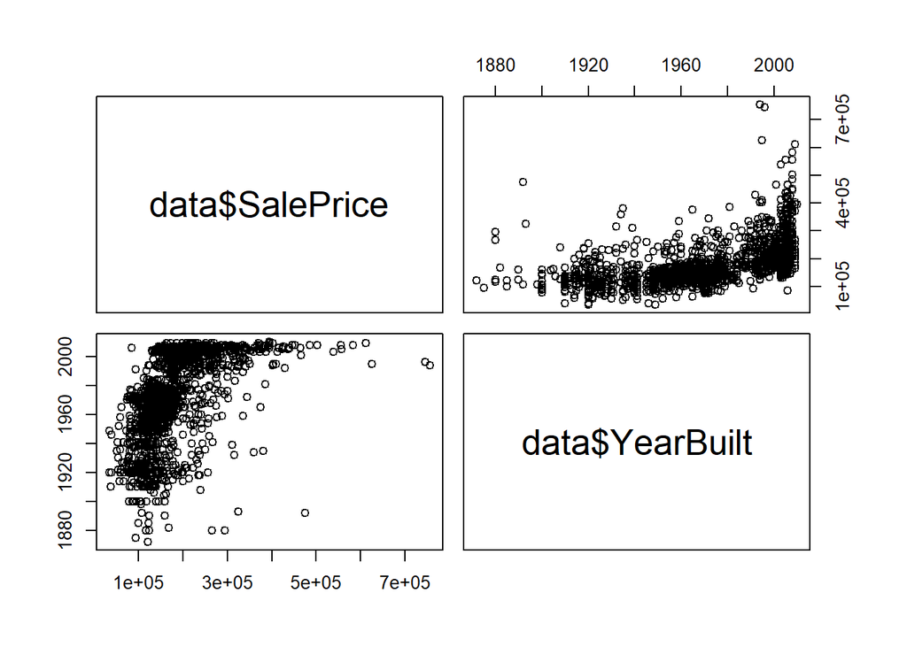

```r
pairs(data$SalePrice ~ data$YearBuilt)
```

Ahora con la variable YearBuilt se ve que no hay mucha correlación (0.5228973), sin embargo aporta significativamente al modelo.

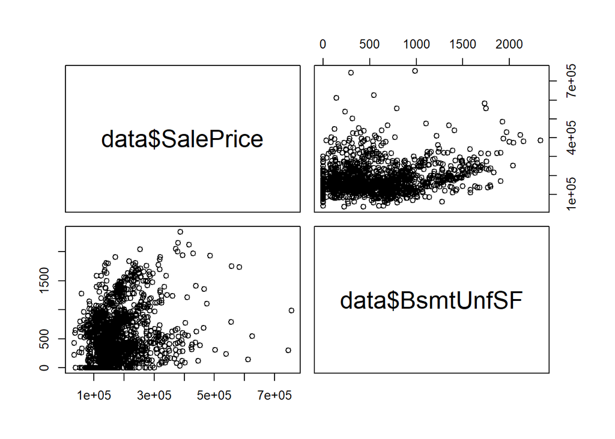

```r
pairs(data$SalePrice ~ data$BsmtUnfSF)
```

Respecto a la variable BsmtUnfSF, se observa que no posee una buena correlacion, teniendo una correlacion de 0.2144791.

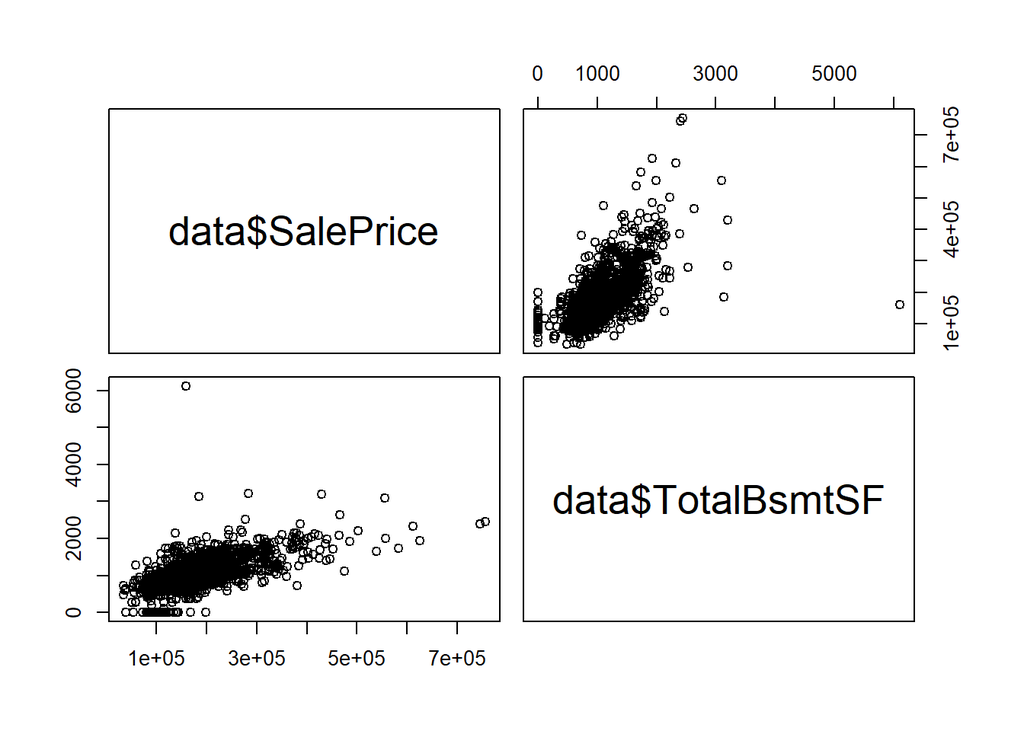

```r
pairs(data$SalePrice ~ data$TotalBsmtSF)
```

La correlación de la variable TotalBsmtSF tiene una correlacion de 0.6135806 siendo mejor que la anterior, ya que nuevamente esta muy cercana a 1.

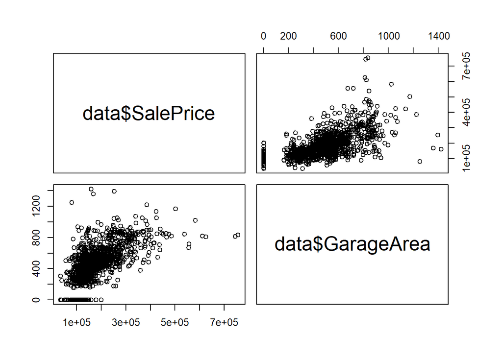

```r
pairs(data$SalePrice ~ data$GarageArea)
```

La variable GarageArea también es útil porque tiene una correlación 0.6234314

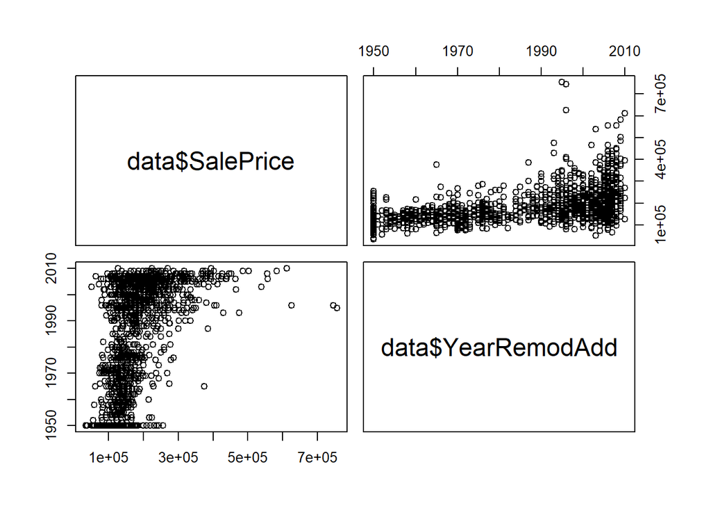

```r
pairs(data$SalePrice ~ data$YearRemodAdd)
```

Con respecto a la variable YearRemodAdd, la correlación es de 0.507101, indicando que puede llegar a ser util, ya que posee una correlacion mayor a 0.5.

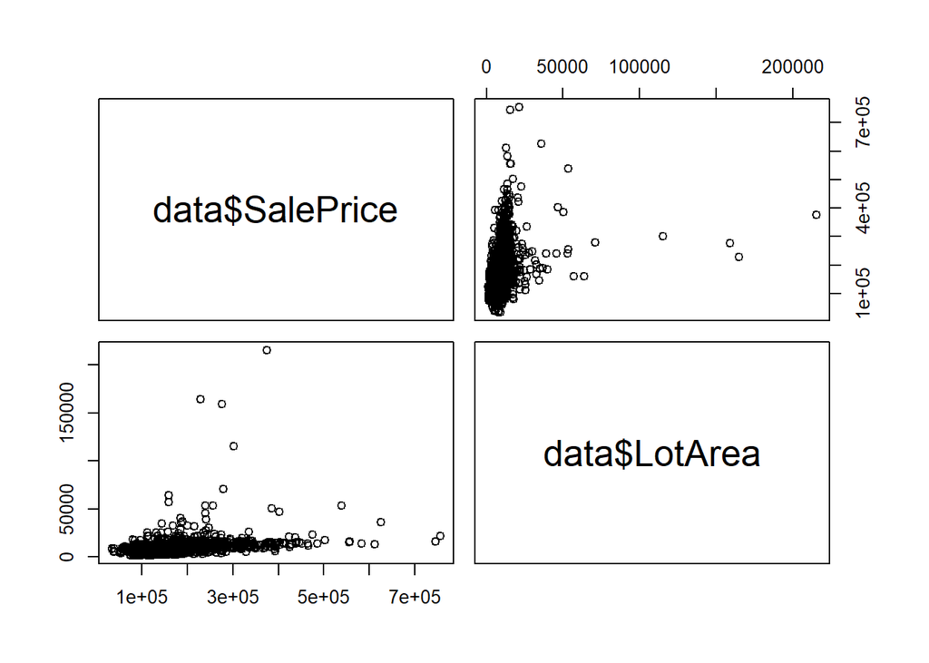

```r
pairs(data$SalePrice ~ data$LotArea)
```

La variable LotArea tiene una correlación de 0.2638434 demostrando que esta no es una buena variable para la regresion lineal.

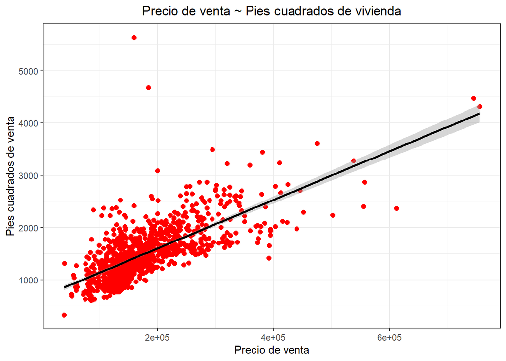

```r
ggplot(data=train,mapping = aes(x=SalePrice,y=GrLivArea ))+
  geom_point(color='red',size=2)+
  geom_smooth(method = 'lm',se=TRUE,color='black')+
  labs(title = 'Precio de venta ~ Pies cuadrados de vivienda',x="Precio de venta",y='Pies cuadrados de venta')+
  theme_bw()+theme(plot.title = element_text(hjust = 0.5))
```

Como se observa en la grafica, mediante la variable con mayor correlacion, en este caso es la variable, GrLivArea. Logramos obtener el modelo lineal, el cual la linea es la que nos minizima el error medio cuadrado. Ademas, como se observa en la grafica, se observa que muchos datos no se encuentran sobre la linea, indicando que no existe overfitting, ya que para que ello exista, se tendria todos los puntos sobre la linea, lo cual como se observa no tenemos.

### Determine la calidad del modelo realizando un análisis de los residuos.

Los residuales se calculan restando del valor de y ajustado del valor de y. Usando una ecuacion podemos predecir el precio de la venta de las casas para el conjunto de pruebas.

```r
summary(predL)
```

```
##    Min. 1st Qu.  Median    Mean 3rd Qu.    Max.
##   24553  129962  177372  178656  223399  398533
```

```r
summary(test$SalePrice)
```

```
##    Min. 1st Qu.  Median    Mean 3rd Qu.    Max.
##   34900  130000  167500  181337  214600  625000
```

Como se observa mediante el summary de ambas variables, tanto en la variable que predijo y la variable del testeo, se demuestra que obtuvimos una buena prediccion, ya que segun el resumen, tenemos varios datos similares, tal como se observa en el promedio. Ahora veamos esto graficamente.

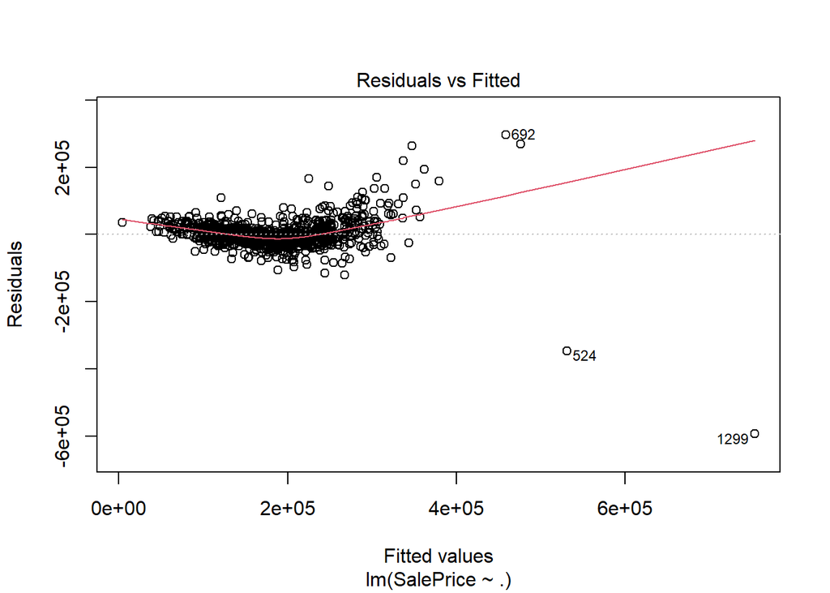

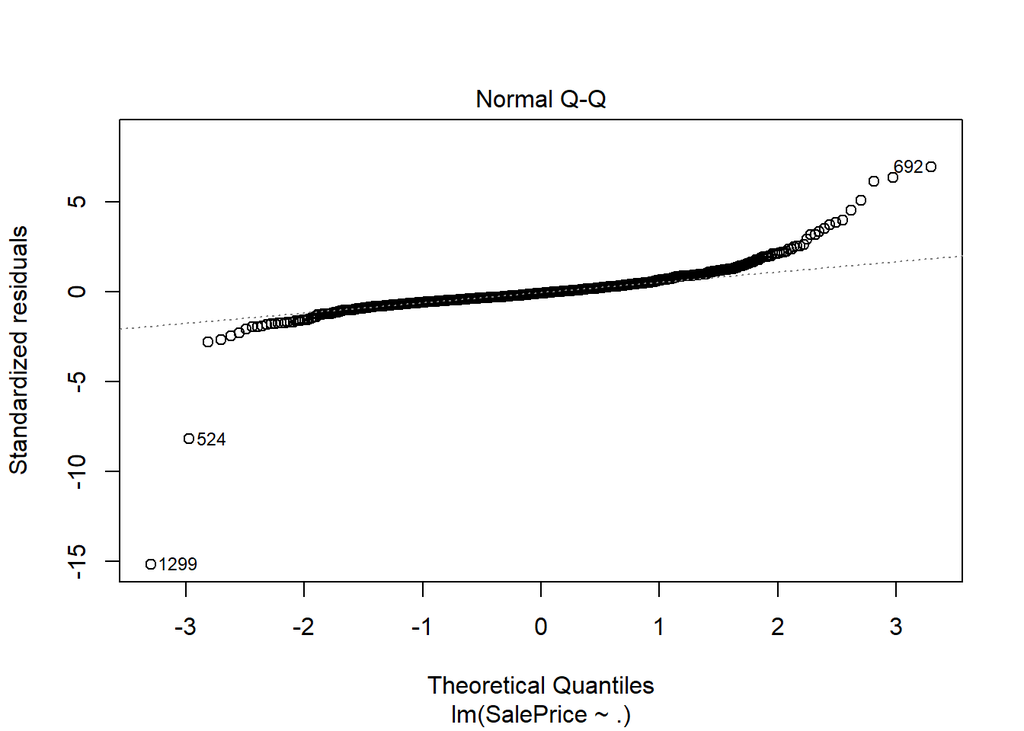

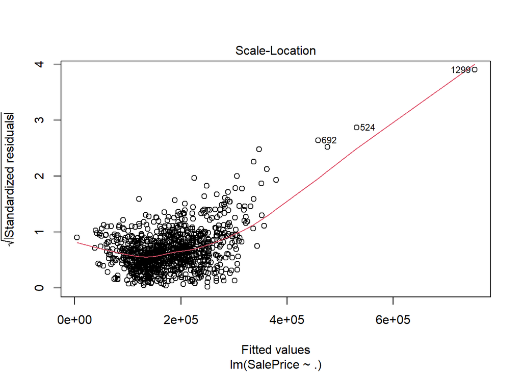

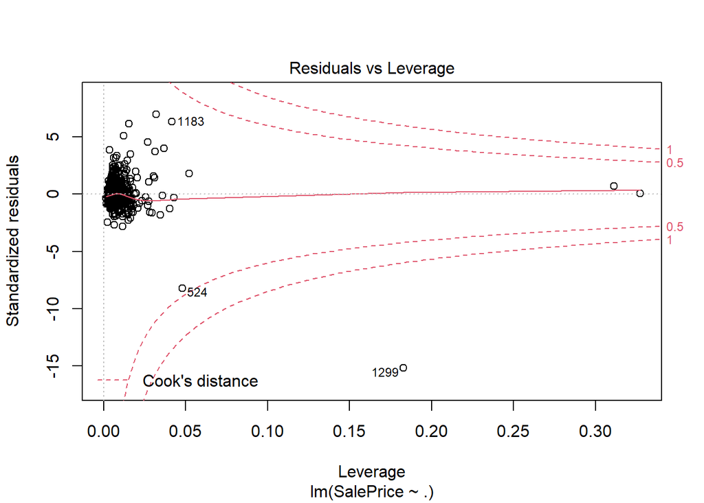

```r
plot(fitLMPW)
```